# Looking Back on 2022

Author

Rick Dean

Abstract

The following notes/R scripts were inspired from an article [Looking Back on 2018](http://www.reproduciblefinance.com/2019/01/14/looking-back-on-last-year/) by Jonathan Regenstein.

```r
library(data.table)
library(magrittr)
library(ggplot2)
library(purrr)
library(grid)
library(gtable)
library(quantmod)
library(RplotterPkg)
library(RstocksPkg)
```

# 1 Looking Back on 2022

## 1.1 The data

Get the daily prices.

Name 10 sector Exchange-Traded Funds (ETF’s i.e. sector indexes) plus the SP500 index (SPY) along with their corresponding sector labels.

```r
symbol_sector_dt <- data.table::data.table(
  Symbol = c("XLY", "XLP", "XLE",
          "XLF", "XLV", "XLI", "XLB",
          "XLK", "XLU", "XLRE",
          "SPY"),
  Sector = c("Consumer Discretionary", "Consumer Staples", "Energy",
          "Financials", "Health Care", "Industrials", "Materials",
          "Information Technology", "Utilities", "Real Estate",
          "Market")
)
```

Get the daily prices for 2022 for the symbols:

```r
prices_dt <- RstocksPkg::get_stock_prices(
  symbols = symbol_sector_dt$Symbol,
  from = "2021-12-31",
  to = "2022-12-31",
  periodicity = "daily"
  ) %>%
.[, .(Symbol, Date, Adjusted)]
```

Outer join both `ticker_sector_dt` and `prices_dt` using *Symbol* as the key.

```r
data.table::setkey(symbol_sector_dt, "Symbol")
data.table::setkey(prices_dt, "Symbol")
prices_dt <- prices_dt[symbol_sector_dt] %>%
.[, Sector := as.factor(Sector)]
```

Group by sector and show the first index

```r
first_index_dt <- prices_dt[, .SD[1], by = Sector]

RplotterPkg::create_table(
  x = first_index_dt,
  container_width_px = 400
)
```

First sector prices at 2021-12-31

| Sector | Symbol | Date | Adjusted |
| --- | --- | --- | --- |
| Market | SPY | 2021-12-31 | 467.37759 |
| Materials | XLB | 2021-12-31 | 88.57157 |
| Energy | XLE | 2021-12-31 | 53.22991 |
| Financials | XLF | 2021-12-31 | 38.24924 |
| Industrials | XLI | 2021-12-31 | 104.00156 |
| Information Technology | XLK | 2021-12-31 | 172.17877 |
| Consumer Staples | XLP | 2021-12-31 | 75.15833 |
| Real Estate | XLRE | 2021-12-31 | 50.07408 |
| Utilities | XLU | 2021-12-31 | 69.49719 |
| Health Care | XLV | 2021-12-31 | 138.73467 |
| Consumer Discretionary | XLY | 2021-12-31 | 202.67448 |

All showing the starting date of 2021-12-31

Group by Sector and compute the daily return

The *DailyReturn* column is the log10 difference between the current adjusted value and its prior daily adjusted value.

```r
prices_daily_return_dt <- prices_dt[, DailyReturn := log10(Adjusted) - log10(shift(Adjusted, 1)), by = Sector] %>%
na.omit(cols = "DailyReturn")
```

Tabulate the first *DailyReturn* of each sector group (2022-01-03)

```r
prices_daily_return_1st_dt  <- prices_daily_return_dt[, .SD[1], by = Sector]

RplotterPkg::create_table(
  x = prices_daily_return_1st_dt,
  container_width_px = 400
)
```

First daily return for each sector

| Sector | Symbol | Date | Adjusted | DailyReturn |
| --- | --- | --- | --- | --- |
| Market | SPY | 2022-01-03 | 470.08365 | 2.507257e-03 |
| Materials | XLB | 2022-01-03 | 87.41813 | -5.692841e-03 |
| Energy | XLE | 2022-01-03 | 54.87956 | 1.325489e-02 |
| Financials | XLF | 2022-01-03 | 38.71940 | 5.305820e-03 |
| Industrials | XLI | 2022-01-03 | 103.14643 | -3.585665e-03 |
| Information Technology | XLK | 2022-01-03 | 173.81274 | 4.102010e-03 |
| Consumer Staples | XLP | 2022-01-03 | 75.14858 | -5.634878e-05 |
| Real Estate | XLRE | 2022-01-03 | 49.61017 | -4.042324e-03 |
| Utilities | XLU | 2022-01-03 | 68.80785 | -4.329244e-03 |
| Health Care | XLV | 2022-01-03 | 137.30687 | -4.492723e-03 |
| Consumer Discretionary | XLY | 2022-01-03 | 208.49377 | 1.229401e-02 |

Plot the *DailyReturn* across time for each sector group

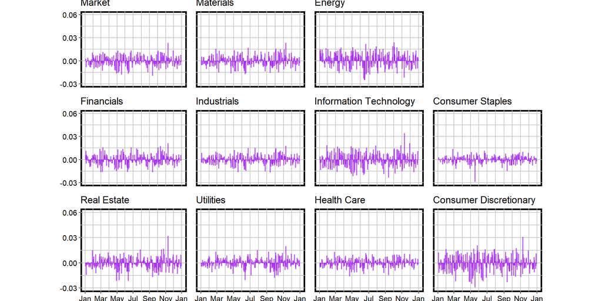

DailyReturn across time for each sector group in 2022

```r
build_plot <- function(id, dt, sectors){
  sector <- sectors[[id]]
  plot_dt <- dt[Sector == sector, ]

  hide_x_tics <- TRUE
  if(id %in% c(8,9,10,11)){
    hide_x_tics <- FALSE
  }

  hide_y_tics <- TRUE
  if(id %in% c(1,4,8)){
    hide_y_tics <- FALSE
  }

  a_plot <- RplotterPkg::create_stick_plot(
    df = plot_dt,
    aes_x = "Date",
    aes_y = "DailyReturn",
    subtitle = sector,
    rot_y_tic_label = T,
    x_limits = as.Date(c("2022-01-01", "2023-01-01")),
    x_major_breaks = seq(as.Date("2022-01-01"), as.Date("2023-01-01"), by="2 month"),
    x_date_labels = "%b",
    y_limits = c(-0.03, 0.06),
    y_major_breaks = seq(-0.03, 0.06, 0.03),
    hide_x_tics = hide_x_tics,
    hide_y_tics = hide_y_tics,
    line_color = "purple",
    line_alpha = 0.7
  )
  return(a_plot)
}
sectors <- symbol_sector_dt$Sector
plots_lst <- purrr::map(1:11, build_plot, dt = prices_daily_return_dt, sectors = sectors)
layout <- list(
  plots = plots_lst,
  rows = c(1, 1, 1, 2, 2, 2, 2, 3, 3, 3, 3),
  cols = c(1, 2, 3, 1, 2, 3, 4, 1, 2, 3, 4)
)
multi_panel_grid(
  layout = layout,
  col_widths = c(6.8, 6, 6, 6),
  row_heights = c(5, 5, 5.8)
)
```

## 1.2 Plot positive and negative prices

Create two numeric variables *ReturnPos* and *ReturnNeg*.

```r
prices_pos_neg_dt <- prices_daily_return_dt[, .(Sector, Date, DailyReturn, ReturnPos = ifelse(DailyReturn > 0, DailyReturn, 0.0), ReturnNeg = ifelse(DailyReturn < 0, DailyReturn, 0.0))]

RplotterPkg::create_table(
  x = prices_pos_neg_dt[1:6,],
  container_width_px = 400
)
```

ReturnPos and ReturnNeg columns based on DailyReturn value

| Sector | Date | DailyReturn | ReturnPos | ReturnNeg |
| --- | --- | --- | --- | --- |
| Market | 2022-01-03 | 0.0025072568 | 0.002507257 | 0.0000000000 |
| Market | 2022-01-04 | -0.0001454502 | 0.000000000 | -0.0001454502 |
| Market | 2022-01-05 | -0.0084204909 | 0.000000000 | -0.0084204909 |
| Market | 2022-01-06 | -0.0004082076 | 0.000000000 | -0.0004082076 |
| Market | 2022-01-07 | -0.0017203562 | 0.000000000 | -0.0017203562 |
| Market | 2022-01-10 | -0.0005407687 | 0.000000000 | -0.0005407687 |

Create a “long” dataframe by reshaping `prices_pos_neg_dt`involving variables *ReturnPos* and *ReturnNeg*.

```r
pos_neg_long_dt <- data.table::melt(prices_pos_neg_dt,
                      id.vars = c("Sector","Date"),
                      measure.vars = c("ReturnPos", "ReturnNeg"),
                      variable.name = "Direction", value.name = "DailyReturn")
```

Plot the two directions across sectors.

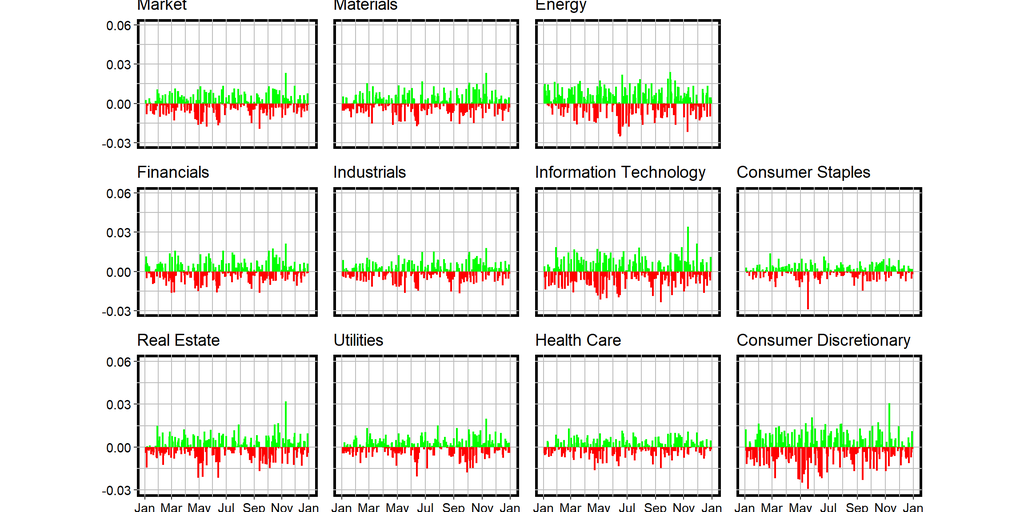

2022 Net Daily Returns

```r
build_plot <- function(id, dt, sectors){
  sector <- sectors[[id]]
  plot_dt <- dt[Sector == sector, ]

  hide_x_tics <- TRUE
  if(id %in% c(8,9,10,11)){
    hide_x_tics <- FALSE
  }

  hide_y_tics <- TRUE
  if(id %in% c(1,4,8)){
    hide_y_tics <- FALSE
  }

  a_plot <- RplotterPkg::create_stick_plot(
    df = plot_dt,
    aes_x = "Date",
    aes_y = "DailyReturn",
    aes_color = "Direction",
    subtitle = sector,
    rot_y_tic_label = T,
    x_limits = as.Date(c("2022-01-01", "2023-01-01")),
    x_major_breaks = seq(as.Date("2022-01-01"), as.Date("2023-01-01"), by="2 month"),
    x_date_labels = "%b",
    y_limits = c(-0.03, 0.06),
    y_major_breaks = seq(-0.03, 0.06, 0.03),
    hide_x_tics = hide_x_tics,
    hide_y_tics = hide_y_tics,
    show_legend = FALSE
  ) +
    ggplot2::scale_color_manual(
      values = c("green","red")
    )

  return(a_plot)
}
sectors <- symbol_sector_dt$Sector
plots_lst <- purrr::map(1:11, build_plot, dt = pos_neg_long_dt, sectors = sectors)
layout <- list(
  plots = plots_lst,
  rows = c(1, 1, 1, 2, 2, 2, 2, 3, 3, 3, 3),
  cols = c(1, 2, 3, 1, 2, 3, 4, 1, 2, 3, 4)
)
multi_panel_grid(
  layout = layout,
  col_widths = c(6.8, 6, 6, 6),
  row_heights = c(5,5,5.8)
)
```

## 1.3 Plot Information Technology

Filter out “Information Technology” sector.

```r
info_tech_dt <- pos_neg_long_dt[Sector == "Information Technology"]
```

Plot the positive and negative:

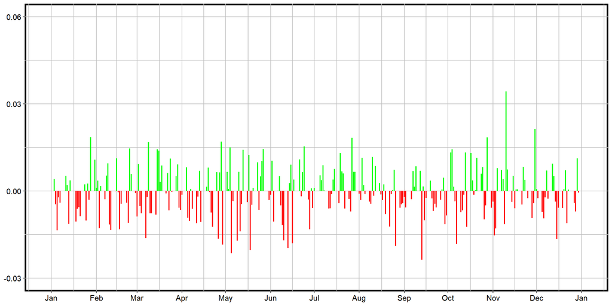

2022 Information Tech Net Daily Returns

```r
RplotterPkg::create_stick_plot(
  df = info_tech_dt,
  aes_x = "Date",
  aes_y = "DailyReturn",
  aes_color = "Direction",
  rot_y_tic_label = T,
  x_limits = as.Date(c("2022-01-01", "2023-01-01")),
  x_major_breaks = seq(as.Date("2022-01-01"), as.Date("2023-01-01"), by="1 month"),
  x_date_labels = "%b",
  y_limits = c(-0.03, 0.06),
  y_major_breaks = seq(-0.03, 0.06, 0.03),
  show_legend = F
) +
  ggplot2::scale_color_manual(
    values = c("green","red")
  )
```